# Wednesday - Jumpstart 2026: Statistics in R

Kylie Falcione

2026-08-16

# Welcome Back to Jumpstart 2026!

Today we’ll learn how to conduct statistical analyses in R using your communication research data. We’ll cover the most common statistical tests used in communication.

## Today’s Learning Goals:

- Understand when to use different statistical tests
- Learn to run and interpret statistical analyses in R
- Practice with real communication research scenarios
- Develop skills in hypothesis testing and interpretation

# Loading Our Communication Data

Let’s start by loading the datasets we’ll use for today’s analyses:

```r
# Load our communication research datasets
media_trust <- read_csv(here("data", "media_trust_survey.csv"))
social_media <- read_csv(here("data", "social_media_engagement.csv"))
news_consumption <- read_csv(here("data", "news_consumption_patterns.csv"))
```

## Quick Data Exploration

Before running any statistics, always explore your data first:

```r
# Explore the media trust dataset
glimpse(media_trust)
```

```
## Rows: 250
## Columns: 10
## $ participant_id     <chr> "P001", "P002", "P003", "P004", "P005", "P006", "P0…
## $ age                <dbl> 30, 29, 53, 43, 18, 40, 27, 30, 66, 29, 21, 44, 40,…
## $ gender             <chr> "Female", "Female", "Male", "Prefer not to say", "F…
## $ education          <chr> "Bachelor's", "Bachelor's", "Bachelor's", "High Sch…
## $ news_source        <chr> "Facebook", "Online News Sites", "Online News Sites…
## $ daily_news_minutes <dbl> 112, 75, 169, 114, 55, 29, 42, 177, 91, 170, 133, 1…
## $ political_interest <dbl> 5, 3, 3, 4, 3, 5, 2, 2, 4, 4, 5, 5, 4, 3, 4, 1, 5, …
## $ income_bracket     <chr> "$75k-$100k", "Under $25k", "$75k-$100k", "Under $2…
## $ trust_score        <dbl> 1.5, 1.0, 4.7, 3.3, 2.5, 5.0, 4.7, 4.3, 4.7, 7.0, 3…
## $ credibility_rating <dbl> 3.1, 1.0, 6.4, 5.0, 4.1, 7.0, 5.7, 6.4, 4.8, 7.0, 3…
```

```r
summary(media_trust$trust_score)
```

```
##    Min. 1st Qu.  Median    Mean 3rd Qu.    Max.
##   1.000   2.725   3.700   3.702   4.700   7.000
```

```r
summary(media_trust$age)
```

```
##    Min. 1st Qu.  Median    Mean 3rd Qu.    Max.
##   18.00   33.00   47.00   47.38   62.75   75.00
```

```r
# Check for missing values
sum(is.na(media_trust$trust_score))
```

```
## [1] 0
```

```r
# Look at the distribution of categorical variables
table(media_trust$news_source)
```

```
##
##          Facebook         Instagram        Newspapers Online News Sites
##                28                38                25                32
##          Podcasts        Television           Twitter           YouTube
##                30                34                25                38
```

```r
table(media_trust$gender)
```

```
##
##            Female              Male        Non-binary Prefer not to say
##               124               104                14                 8
```

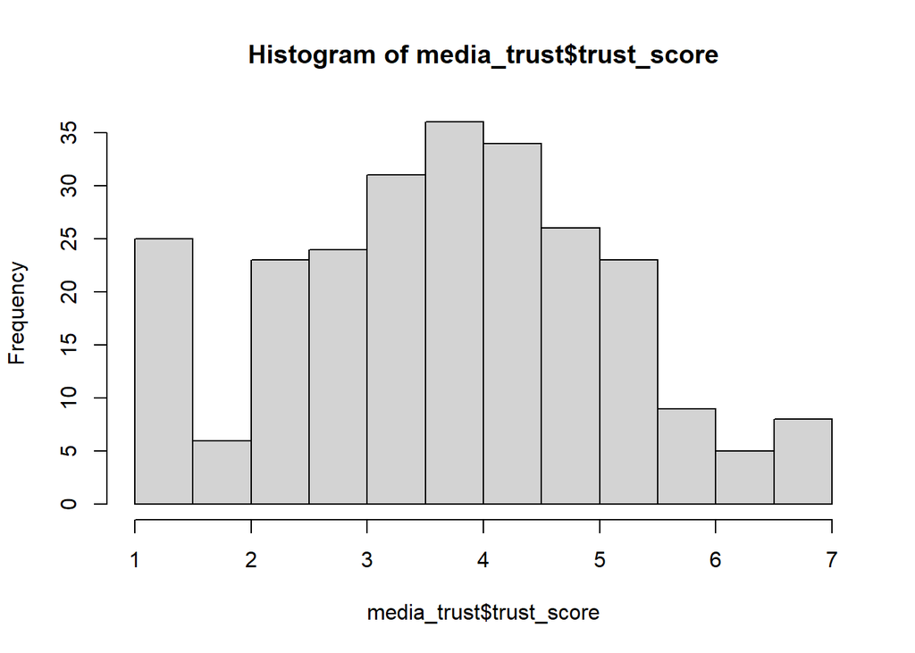

```r
#For most statistical tests, we want to have a normal distribution of data
#Visually inspect distribution. The 'hist' function creates a histogram of the data
hist(media_trust$trust_score)
```

```r
#Statistically check. We can test this with a Shapiro-Wilk's test of normality.
#p < 0.05 indicates that the data significantly deviates from a normal distribution.
shapiro.test(media_trust$trust_score)
```

```
##
##  Shapiro-Wilk normality test
##
## data:  media_trust$trust_score
## W = 0.98615, p-value = 0.01608
```

```r
#To get the metrics of normality (skew and kurtosis), you can use a package called 'psych'
#The 'psych' package gives you more relevant descriptive information, like skew and kurtosis, to understand the distribution of your data
# install.packages("psych")
# library(psych)
# describe(media_trust$trust_score)

#In your stats courses you will learn more about how to address not normally distributed data
```

# Statistical Tests in Communication Research

## 1. One-Sample t-Test

**When to use:** Test if a sample mean differs from a known population value or theoretical expectation.

**Research Question:** “Do participants’ trust scores differ significantly from the scale midpoint (4.0)?”

```r
# One-sample t-test: Is trust score significantly different from midpoint?
one_sample_result <- t.test(media_trust$trust_score, mu = 4.0)
one_sample_result
```

```
##
##  One Sample t-test
##
## data:  media_trust$trust_score
## t = -3.34, df = 249, p-value = 0.0009661
## alternative hypothesis: true mean is not equal to 4
## 95 percent confidence interval:
##  3.526913 3.877887
## sample estimates:
## mean of x
##    3.7024
```

## 2. Independent Samples t-Test

**When to use:** Compare means between two independent groups.

**Research Question:** “Do males and females differ in their trust scores?”

```r
# Filter for just male and female participants
gender_comparison <- media_trust %>%
  filter(gender %in% c("Male", "Female"))

# Descriptive statistics by group
gender_comparison %>%
  group_by(gender) %>%
  summarize(
    mean_trust = mean(trust_score, na.rm = TRUE),
    sd_trust = sd(trust_score, na.rm = TRUE),
    n = n()
  )
```

```
## # A tibble: 2 × 4
##   gender mean_trust sd_trust     n
##   <chr>       <dbl>    <dbl> <int>
## 1 Female       3.68     1.47   124
## 2 Male         3.72     1.37   104
```

```r
# Independent samples t-test (DV ~ IV, data = df)
independent_t_result <- t.test(trust_score ~ gender, data = gender_comparison)
independent_t_result
```

```
##
##  Welch Two Sample t-test
##
## data:  trust_score by gender
## t = -0.23128, df = 223.21, p-value = 0.8173
## alternative hypothesis: true difference in means between group Female and group Male is not equal to 0
## 95 percent confidence interval:
##  -0.4146033  0.3275065
## sample estimates:
## mean in group Female   mean in group Male
##             3.681452             3.725000
```

## 3. Paired Samples t-Test

**When to use:** Compare two related measurements from the same participants.

**Research Question:** “Do trust scores and credibility ratings differ significantly?”

```r
# Paired samples t-test: trust vs credibility ratings
paired_t_result <- t.test(media_trust$trust_score,
                         media_trust$credibility_rating,
                         paired = TRUE)
paired_t_result
```

```
##
##  Paired t-test
##
## data:  media_trust$trust_score and media_trust$credibility_rating
## t = -9.795, df = 249, p-value < 0.00000000000000022
## alternative hypothesis: true mean difference is not equal to 0
## 95 percent confidence interval:
##  -0.6750046 -0.4489954
## sample estimates:
## mean difference
##          -0.562
```

```r
# Descriptive statistics
cat("Mean trust score:", round(mean(media_trust$trust_score, na.rm = TRUE), 2), "\n")
```

```
## Mean trust score: 3.7
```

```r
cat("Mean credibility rating:", round(mean(media_trust$credibility_rating, na.rm = TRUE), 2))
```

```
## Mean credibility rating: 4.26
```

## 4. Linear Regression

**When to use:** Predict one continuous variable from another continuous variable.

**Research Question:** “Does age predict trust in news sources?”

```r
# Simple linear regression lm(DV ~ IV), data = df)
trust_age_model <- lm(trust_score ~ age, data = media_trust)
summary(trust_age_model)
```

```
##
## Call:
## lm(formula = trust_score ~ age, data = media_trust)
##
## Residuals:
##     Min      1Q  Median      3Q     Max
## -2.5913 -0.8067 -0.0751  0.7316  4.1572
##
## Coefficients:
##             Estimate Std. Error t value             Pr(>|t|)
## (Intercept) 1.486181   0.223410   6.652       0.000000000183 ***
## age         0.046779   0.004448  10.518 < 0.0000000000000002 ***
## ---
## Signif. codes:  0 '***' 0.001 '**' 0.01 '*' 0.05 '.' 0.1 ' ' 1
##
## Residual standard error: 1.174 on 248 degrees of freedom
## Multiple R-squared:  0.3085, Adjusted R-squared:  0.3057
## F-statistic: 110.6 on 1 and 248 DF,  p-value: < 0.00000000000000022
```

## 5. Multiple Regression

**When to use:** Predict one variable from multiple predictors.

**Research Question:** “Do age, political interest, and daily news consumption predict trust scores?”

```r
# Multiple regression lm(DV ~ IV1 + IV2 + IV3, data = df)
multiple_model <- lm(trust_score ~ age + political_interest + daily_news_minutes,
                    data = media_trust)

summary(multiple_model)
```

```
##
## Call:
## lm(formula = trust_score ~ age + political_interest + daily_news_minutes,
##     data = media_trust)
##
## Residuals:
##     Min      1Q  Median      3Q     Max
## -2.5816 -0.7754 -0.0473  0.6651  3.8970
##
## Coefficients:
##                     Estimate Std. Error t value             Pr(>|t|)
## (Intercept)         1.222122   0.324560   3.765             0.000208 ***
## age                 0.046701   0.004419  10.569 < 0.0000000000000002 ***
## political_interest -0.012244   0.048279  -0.254             0.800017
## daily_news_minutes  0.003386   0.001427   2.373             0.018431 *
## ---
## Signif. codes:  0 '***' 0.001 '**' 0.01 '*' 0.05 '.' 0.1 ' ' 1
##
## Residual standard error: 1.165 on 246 degrees of freedom
## Multiple R-squared:  0.324,  Adjusted R-squared:  0.3158
## F-statistic:  39.3 on 3 and 246 DF,  p-value: < 0.00000000000000022
```

## 6. Correlation Analysis

**When to use:** Examine the strength and direction of relationships between variables.

**Research Question:** “How strongly are trust scores and credibility ratings related?”

```r
# Pearson correlation cor.test( ~ Iv + DV, data = df), cor.test(df$IV, df$DV)
correlation_result <- cor.test( ~ credibility_rating + trust_score, data = media_trust)

print(correlation_result)
```

```
##
##  Pearson's product-moment correlation
##
## data:  credibility_rating and trust_score
## t = 22.542, df = 248, p-value < 0.00000000000000022
## alternative hypothesis: true correlation is not equal to 0
## 95 percent confidence interval:
##  0.7744684 0.8567024
## sample estimates:
##       cor
## 0.8197672
```

## 7. One-Way ANOVA

**When to use:** Compare means across three or more groups.

**Research Question:** “Do trust scores differ across education levels?”

```r
# One-way ANOVA aov(DV ~ IV, data = df)
anova_model <- aov(trust_score ~ education, data = media_trust)
summary(anova_model)
```

```
##              Df Sum Sq Mean Sq F value Pr(>F)
## education     4    7.2   1.808    0.91  0.459
## Residuals   245  487.0   1.988
```

## 8. Two-Way ANOVA

**When to use:** Examine effects of two categorical variables and their interaction.

**Research Question:** “Do trust scores vary by gender and education level?”

```r
# Filter for main gender categories for cleaner analysis
anova_data <- media_trust %>%
  filter(gender %in% c("Male", "Female")) %>%
  filter(education %in% c("Bachelor's", "Master's", "PhD"))

# Two-way ANOVA aov(DV ~ IV1 * IV2, data = df )
twoway_model <- aov(trust_score ~ gender * education, data = anova_data)
summary(twoway_model)
```

```
##                   Df Sum Sq Mean Sq F value Pr(>F)
## gender             1   4.00   4.003   1.713  0.193
## education          2   1.83   0.913   0.391  0.677
## gender:education   2   4.57   2.286   0.978  0.379
## Residuals        132 308.46   2.337
```

```r
# Means by group
anova_data %>%
  group_by(gender, education) %>%
  summarize(
    mean_trust = mean(trust_score, na.rm = TRUE),
    n = n(),
    .groups = 'drop'
  )
```

```
## # A tibble: 6 × 4
##   gender education  mean_trust     n
##   <chr>  <chr>           <dbl> <int>
## 1 Female Bachelor's       3.45    42
## 2 Female Master's         3.51    26
## 3 Female PhD              3.82     8
## 4 Male   Bachelor's       4.13    31
## 5 Male   Master's         3.46    19
## 6 Male   PhD              3.74    12
```

## 9. Chi-Square Goodness of Fit

**When to use:** Test if observed frequencies match expected frequencies.

**Research Question:** “Are news sources equally preferred among participants?”

```r
# Chi-square goodness of fit test
news_source_table <- table(media_trust$news_source)
news_source_table
```

```
##
##          Facebook         Instagram        Newspapers Online News Sites
##                28                38                25                32
##          Podcasts        Television           Twitter           YouTube
##                30                34                25                38
```

```r
chisq_goodness <- chisq.test(news_source_table)
chisq_goodness
```

```
##
##  Chi-squared test for given probabilities
##
## data:  news_source_table
## X-squared = 6.064, df = 7, p-value = 0.5323
```

```r
# Expected vs observed frequencies
data.frame(
  News_Source = names(news_source_table),
  Observed = as.numeric(news_source_table),
  Expected = round(chisq_goodness$expected, 1)
)
```

```
##                         News_Source Observed Expected
## Facebook                   Facebook       28     31.2
## Instagram                 Instagram       38     31.2
## Newspapers               Newspapers       25     31.2
## Online News Sites Online News Sites       32     31.2
## Podcasts                   Podcasts       30     31.2
## Television               Television       34     31.2
## Twitter                     Twitter       25     31.2
## YouTube                     YouTube       38     31.2
```

## 10. Chi-Square Test of Independence

**When to use:** Test if two categorical variables are independent.

**Research Question:** “Is there an association between gender and preferred news source?”

```r
# Create contingency table
contingency_table <- table(gender_comparison$gender, gender_comparison$news_source)
contingency_table
```

```
##
##          Facebook Instagram Newspapers Online News Sites Podcasts Television
##   Female       12        16          9                17       14         18
##   Male         13        17         15                15       12         11
##
##          Twitter YouTube
##   Female      16      22
##   Male         9      12
```

```r
# Chi-square test of independence
chisq_independence <- chisq.test(contingency_table)
chisq_independence
```

```
##
##  Pearson's Chi-squared test
##
## data:  contingency_table
## X-squared = 6.7374, df = 7, p-value = 0.4567
```

## 11. Logistic Regression

**When to use:** Predict a binary outcome from one or more predictors.

**Research Question:** “What factors predict high trust (above median) in news sources?”

```r
# Create binary outcome variable NA or NaN
media_trust <- media_trust %>%
  mutate(high_trust = ifelse(trust_score > median(trust_score, na.rm = TRUE), 1, 0)) #na.rm = remove missing values

# Logistic regression
logistic_model <- glm(high_trust ~ age + political_interest + daily_news_minutes,
                     data = media_trust,
                     family = binomial)

summary(logistic_model)
```

```
##
## Call:
## glm(formula = high_trust ~ age + political_interest + daily_news_minutes,
##     family = binomial, data = media_trust)
##
## Coefficients:
##                     Estimate Std. Error z value          Pr(>|z|)
## (Intercept)        -4.218436   0.744029  -5.670 0.000000014303426 ***
## age                 0.080067   0.010512   7.617 0.000000000000026 ***
## political_interest -0.115828   0.100501  -1.153           0.24911
## daily_news_minutes  0.008773   0.003051   2.876           0.00403 **
## ---
## Signif. codes:  0 '***' 0.001 '**' 0.01 '*' 0.05 '.' 0.1 ' ' 1
##
## (Dispersion parameter for binomial family taken to be 1)
##
##     Null deviance: 346.32  on 249  degrees of freedom
## Residual deviance: 259.60  on 246  degrees of freedom
## AIC: 267.6
##
## Number of Fisher Scoring iterations: 4
```

# Practice Exercises: Your Turn!

Now it’s time to practice with our social media engagement dataset!

## Data Exploration (Always Start Here!)

```r
# Explore the social media dataset
glimpse(social_media)
```

```
## Rows: 300
## Columns: 10
## $ user_id                <chr> "U001", "U002", "U003", "U004", "U005", "U006",…
## $ age                    <dbl> 44, 31, 52, 64, 22, 54, 28, 54, 41, 26, 51, 27,…
## $ platform               <chr> "Instagram", "Facebook", "Facebook", "Facebook"…
## $ daily_hours            <dbl> 5.9, 4.6, 3.5, 0.4, 7.0, 4.5, 2.2, 2.6, 2.1, 6.…
## $ posts_per_week         <dbl> 5, 1, 9, 6, 4, 3, 3, 4, 4, 3, 2, 2, 1, 5, 6, 1,…
## $ engagement_score       <dbl> 100.0, 51.0, 78.7, 100.0, 49.9, 72.3, 32.3, 82.…
## $ follower_count         <dbl> 65, 24, 366, 5555, 11, 17, 32, 2708, 1265, 25, …
## $ political_posts_week   <dbl> 1, 3, 2, 3, 2, 2, 3, 1, 3, 0, 1, 2, 0, 2, 3, 0,…
## $ news_sharing_frequency <dbl> 2, 2, 2, 2, 4, 1, 1, 1, 2, 4, 2, 4, 2, 2, 3, 1,…
## $ platform_satisfaction  <dbl> 3, 5, 6, 5, 4, 5, 4, 4, 5, 7, 4, 5, 3, 4, 4, 5,…
```

```r
# Your task: Calculate descriptive statistics for 3 variables
# 1. One continuous variable (e.g., engagement_score)
# 2. One categorical variable (e.g., platform)
# 3. One of your choice

# Your code here:
```

## Exercise 1: Independent Samples t-Test

**Research Question:** “Do users who post frequently (>4 posts/week) have different engagement scores than those who post less frequently?”

```r
# Step 1: Create a binary grouping variable
# Step 2: Run an independent samples t-test
# Step 3: Calculate descriptive statistics by group

# Your code here:
```

## Exercise 2: Correlation Analysis

**Research Question:** “What is the relationship between daily hours spent on social media and engagement scores?”

```r
# Step 1: Run a correlation test

# Your code here:
```

## Exercise 3: One-Way ANOVA

**Research Question:** “Do engagement scores differ significantly across social media platforms?”

```r
# Step 1: Run a one-way ANOVA
# Step 2: Calculate descriptive statistics by platform

# Your code here:
```

## Exercise 4: Linear Regression

**Research Question:** “Does follower count predict engagement scores?”

```r
# Step 1: Run a simple linear regression
# Step 2: Examine model fit statistics

# Your code here:
```

## Exercise 5: Chi-Square Test

**Research Question:** “Is there an association between platform type and news sharing frequency (high vs. low)?”

```r
# Step 1: Create a binary news sharing variable (above/below median)
# Step 2: Create a contingency table
# Step 3: Run a chi-square test of independence

# Your code here:
```

## Exercise 6: Multiple Regression

**Research Question:** “What combination of factors (age, daily hours, follower count) best predicts engagement scores?”

```r
# Step 1: Run a multiple regression
# Step 2: Examine which predictors are significant

# Your code here:
```

## Exercise 7: Advanced Challenge

**Research Question:** Design your own analysis! Choose variables from any of our datasets and:

1. State a clear research question
2. Choose the appropriate statistical test
3. Run the analysis
4. Interpret the results

```r
# Your research question:


# Justification for your chosen test:


# Your analysis:




# Your interpretation:
```

# Interpreting Statistical Results

## Key Guidelines for Communication Research:

### P-values:

- **p < 0.001**: Very strong evidence against null hypothesis
- **p < 0.01**: Strong evidence against null hypothesis
- **p < 0.05**: Moderate evidence against null hypothesis
- **p ≥ 0.05**: Insufficient evidence to reject null hypothesis

### Effect Sizes:

- **Cohen’s d** (t-tests): 0.2 (small), 0.5 (medium), 0.8 (large)
- **R-squared** (regression): % of variance explained
- **Eta-squared** (ANOVA): proportion of variance explained
- **Cramér’s V** (chi-square): 0.1 (small), 0.3 (medium), 0.5 (large)

### Reporting Results:

Always include: 1. Descriptive statistics (means, standard deviations) 2. Test statistic and degrees of freedom 3. P-value 4. Effect size 5. Confidence intervals when appropriate

# Best Practices for Statistical Analysis

## Before Running Tests:

1. **Explore your data** - check distributions, outliers, missing values
2. **Check assumptions** - normality, homogeneity of variance, independence
3. **Visualize relationships** - scatter plots, box plots, histograms (we’ll go over this tomorrow!)

## During Analysis:

1. **Use appropriate tests** - match the test to your research question and data type
2. **Consider effect sizes** - statistical significance ≠ practical significance
3. **Check residuals** - especially for regression models

## After Analysis:

1. **Interpret results substantively** - what do they mean for your research question?
2. **Consider limitations** - sample size, generalizability, causation vs. correlation
3. **Report transparently** - include all relevant statistics and confidence intervals

# Next Steps

Excellent work! You’ve now learned:

✅ **Tuesday:** R basics and data manipulation  
✅ **Wednesday:** Statistical analysis in R with communication data

## What’s Coming:

- **Thursday:** Data visualization with ggplot2

Great job building your statistical analysis skills in R! 🎉